# Periódicos potencialmente fradulentos no QUALIS

Presença atual e potencial de expansão

# Resumo Executivo

## Proporção de periódicos predatórios no QUALIS

Dos 26477 periódicos científicos na base QUALIS da CAPES pelo menos 1.9% são potencialmente predatórios.

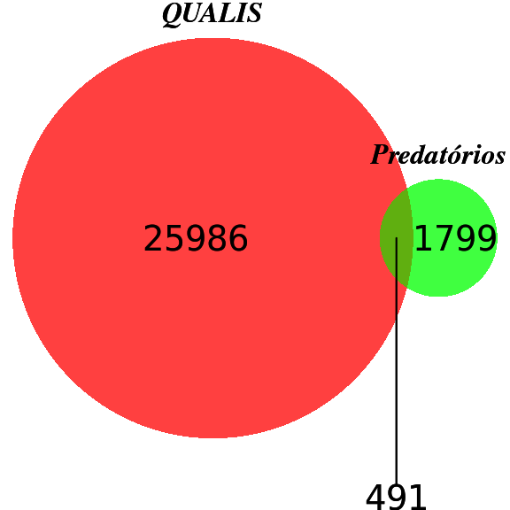

## Capacidade do QUALIS detectar predatórios

- 76.8 % dos títulos potencialmente predatórios foram corretamente classificados no estrato mais baixo (QUALIS C) por pelo menos uma área de conhecimento.
- No entanto 67.4 % dos títulos foram classificados nos estratos A e B por pelo menos uma área.

## Lista interativa dos títulos potencialmente predatórios no QUALIS

A tabela abaixo permite filtrar os títulos potencialmente predatórios por área de conhecimento e conceito, e também buscar periódicos pelo título e INSS. Você pode também usar a caixa de busca para procurar um *string* em qualquer lugar da tabela.

|  | Área | ISSN | Título | Estrato QUALIS |
| --- | --- | --- | --- | --- |
| 55 | ADMINISTRAÇĂO PÚBLICA E DE EMPRESAS, CIÊNCIAS CONTÁBEIS E TURISMO | 2329-888X | ADVANCES IN DAIRY RESEARCH | B4 |
| 158 | ADMINISTRAÇĂO PÚBLICA E DE EMPRESAS, CIÊNCIAS CONTÁBEIS E TURISMO | 2223-5833 | ARABIAN JOURNAL OF BUSINESS AND MANAGEMENT REVIEW | B4 |
| 297 | ADMINISTRAÇĂO PÚBLICA E DE EMPRESAS, CIÊNCIAS CONTÁBEIS E TURISMO | 2151-6219 | BUSINESS AND ECONOMICS JOURNAL | B3 |
| 876 | ADMINISTRAÇĂO PÚBLICA E DE EMPRESAS, CIÊNCIAS CONTÁBEIS E TURISMO | 2304-9693 | EUROPEAN INTERNATIONAL JOURNAL OF SCIENCE AND TECHNOLOGY | B4 |
| 886 | ADMINISTRAÇĂO PÚBLICA E DE EMPRESAS, CIÊNCIAS CONTÁBEIS E TURISMO | 1450-216X | EUROPEAN JOURNAL OF SCIENTIFIC RESEARCH | A2 |
| 1221 | ADMINISTRAÇĂO PÚBLICA E DE EMPRESAS, CIÊNCIAS CONTÁBEIS E TURISMO | 2164-2540 | INTERNATIONAL JOURNAL OF BUSINESS AND SOCIAL RESEARCH | B4 |
| 1232 | ADMINISTRAÇĂO PÚBLICA E DE EMPRESAS, CIÊNCIAS CONTÁBEIS E TURISMO | 2229-6247 | INTERNATIONAL JOURNAL OF BUSINESS MANAGEMENT AND ECONOMIC RESEARCH (IJBMER), | B3 |
| 1242 | ADMINISTRAÇĂO PÚBLICA E DE EMPRESAS, CIÊNCIAS CONTÁBEIS E TURISMO | 0975-833X | INTERNATIONAL JOURNAL OF CURRENT RESEARCH | B4 |
| 1262 | ADMINISTRAÇĂO PÚBLICA E DE EMPRESAS, CIÊNCIAS CONTÁBEIS E TURISMO | 1099-9264 | INTERNATIONAL JOURNAL OF ENTREPRENEURSHIP | B1 |
| 1301 | ADMINISTRAÇĂO PÚBLICA E DE EMPRESAS, CIÊNCIAS CONTÁBEIS E TURISMO | 2349-5219 | INTERNATIONAL JOURNAL OF INNOVATION AND RESEARCH IN EDUCATIONAL SCIENCES | B4 |

[output cut: 2389 more lines]

## Conclusão

Procedimentos de detecção de periódicos predatórios não estão incorporados no QUALIS. A pequena proporção destes periódicos no total de títulos nos quais os programas de PG brasileiros publicam deve estar mais relacionada a opções destes programas do que com a capacidade do sistema coibir ou prevenir isso. Nesta pequena fração a baixa capacidade do sistema de detectar estes periódicos como predatórios indica a vulnerabilidade do QUALIS aos predatórios.

## Recomendações

- Incluir no QUALIS critérios explícitos de triagem de periódicos potencialmente predatórios;
- Exigir das áreas que explicitem seus critérios para identificar predatórios;
- Procedimento para verificar discrepâncias quanto à classificação em predatórios entre áreas.

# Métodos e resultados detalhados

Este é um relatório dinâmico de um trabalho iniciado em novembro de 2017. O objetivo é avaliar a proporção de periódicos listados pelo Sistema QUALIS-CAPES que têm potencial de serem fraudulentos ou predatórios. Também buscamos avaliar as chances de um periódico destes ser detectado pelo sistema.

O QUALIS é a classificação de todos os periódicos em que participantes dos programas de pós-graduação do Brasil publicam seus artigos. A base é usada na avaliação da produção dos programas, um dos principais critérios para [Avaliação Quadrienal dos Programa de Pós-Graduação](http://avaliacaoquadrienal.capes.gov.br/), feita pela CAPES.

As coordenações de cada área de conhecimento da CAPES são responsáveis por compilar os títulos de todos os periódicos e classificá-los em uma escala de relevância com os níveis A1, A2, B1 a B5 e C. Um mesmo título pode receber níveis diferentes em diferentes áreas. Para saber mais veja:

- Barata, R.C.B. 2016. Dez coisas que você deveria saber sobre o QUALIS. [Revista Bras. de Pós-Graduação.](http://ojs.rbpg.capes.gov.br/index.php/rbpg/article/view/947)
- [Perguntas frequentes sobre o QUALIS](http://www.capes.gov.br/acessoainformacao/perguntas-frequentes/avaliacao-da-pos-graduacao/7422-qualis), do site da CAPES.
- [Sobre o QUALIS](https://www.sibi.usp.br/apoio-pesquisador/escrita-publicacao-cientifica/selecao-revistas-publicacao/qualis-periodicos/), da página do Sistema de Bibliotecas da USP.

## Bases de dados usadas

- QUALIS: classificação de todos os periódicos por cada área, para a avaliação dos programas no quadriênio 2013-2016 (https://sucupira.capes.gov.br/);
- Lista de Periódicos com práticas questionáveis criada por Jeffrey Beall. A lista foi tirada do ar[^1] mas há cópias disponíveis em vários sites, (e.g. http://beallslist.weebly.com/) . Extraímos dessa base de dados:
- Standalone Journals List: lista de títulos isolados potencialmente predadores, conforme está na base de Beall;
- Periódicos no Scopus de editoras que estão na lista de Bealls: periódicos incluídos na base Scopus de 2017 (https://www.scopus.com/home.uri) e que são de editoras incluídas nas lista de Bealls.
- Lista de periódicos publicados pela editora OMICS, uma das maiores editoras reconhecidamente predatórias [^2].

## Estatísticas descritivas

- Nossa lista final de periódicos potencialmente predatórios compilada das bases acima totalizou 2290 títulos, sendo: 1312 *standalone* da lista de Beals, 202 no SCOPUS de editoras indicadas na lista de Beals e 782 da editora OMICS.
- Do total de títulos da OMICS, 5 estavam na lista de *standalone* de Beals e 1 estava incluído na SCOPUS entre os publicados por editoras na lista de Beals.
- Entre os potenciais predatórios que constam na SCOPUS, 60 foram cancelados da base em 2017. Uma nota na planilha fornecida pela SCOPUS informa que estes títulos *“do not meet the Scopus quality criteria anymore and therefore Scopus discontinued the forward capturing”*.
- A base QUALIS 2013-2016 tem 26477 titulos, dos quais 491 (1.9%) estão na lista de potenciais predatórios definido acima.
- Os periódicos potencialmente predatórios presentes na QUALIS correspondem a 21.4% da lista que compilamos.

### Áreas de avaliação CAPES e suas divisões

Na avaliação 2013-2016 os programas foram divididos em 49 áreas, reunidas em 9 e três colégios (ciências da vida, exatas e humanas). A classificação de cada área em básica ou aplicada é nossa, para algumas análises estatísticas (masi abaixo).

Áreas da avaliação CAPES 2013-2016. A última coluna foi acrescentada por mim e não faz parte da classificação CAPES

| Colégio | Gde área | Área | Básica/Aplic. |
| --- | --- | --- | --- |
| ENGENHARIAS I | EXATAS | ENGENHARIAS | APPLIED |
| ENGENHARIAS II | EXATAS | ENGENHARIAS | APPLIED |
| ENGENHARIAS III | EXATAS | ENGENHARIAS | APPLIED |
| ENGENHARIAS IV | EXATAS | ENGENHARIAS | APPLIED |
| ASTRONOMIA / FÍSICA | EXATAS | EXATAS E TERRA | BASIC |
| CIÊNCIA DA COMPUTAÇĂO | EXATAS | EXATAS E TERRA | BASIC |
| GEOCIÊNCIAS | EXATAS | EXATAS E TERRA | BASIC |
| MATEMÁTICA / PROBABILIDADE E ESTATÍSTICA | EXATAS | EXATAS E TERRA | BASIC |
| QUÍMICA | EXATAS | EXATAS E TERRA | BASIC |
| BIOTECNOLOGIA | EXATAS | MULTIDISCIPLINAR | APPLIED |
| CIÊNCIAS AMBIENTAIS | EXATAS | MULTIDISCIPLINAR | APPLIED |
| ENSINO | EXATAS | MULTIDISCIPLINAR | APPLIED |
| INTERDISCIPLINAR | EXATAS | MULTIDISCIPLINAR | APPLIED |
| MATERIAIS | EXATAS | MULTIDISCIPLINAR | APPLIED |
| ANTROPOLOGIA / ARQUEOLOGIA | HUMANIDADES | HUMANAS | BASIC |
| CIÊNCIA POLÍTICA E RELAÇƠES INTERNACIONAIS | HUMANIDADES | HUMANAS | BASIC |
| CIÊNCIAS DA RELIGIĂO E TEOLOGIA | HUMANIDADES | HUMANAS | BASIC |
| EDUCAÇĂO | HUMANIDADES | HUMANAS | BASIC |
| FILOSOFIA | HUMANIDADES | HUMANAS | BASIC |
| GEOGRAFIA | HUMANIDADES | HUMANAS | BASIC |
| HISTÓRIA | HUMANIDADES | HUMANAS | BASIC |
| PSICOLOGIA | HUMANIDADES | HUMANAS | BASIC |
| SOCIOLOGIA | HUMANIDADES | HUMANAS | BASIC |
| ARTES / MÚSICA | HUMANIDADES | LETRAS E ARTES | BASIC |
| LETRAS / LINGUÍSTICA | HUMANIDADES | LETRAS E ARTES | BASIC |
| ADMINISTRAÇĂO PÚBLICA E DE EMPRESAS, CIÊNCIAS CONTÁBEIS E TURISMO | HUMANIDADES | SOCIAIS APLICADAS | APPLIED |
| ARQUITETURA, URBANISMO E DESIGN | HUMANIDADES | SOCIAIS APLICADAS | APPLIED |
| COMUNICAÇĂO E INFORMAÇĂO | HUMANIDADES | SOCIAIS APLICADAS | APPLIED |
| DIREITO | HUMANIDADES | SOCIAIS APLICADAS | APPLIED |
| ECONOMIA | HUMANIDADES | SOCIAIS APLICADAS | APPLIED |
| PLANEJAMENTO URBANO E REGIONAL / DEMOGRAFIA | HUMANIDADES | SOCIAIS APLICADAS | APPLIED |
| SERVIÇO SOCIAL | HUMANIDADES | SOCIAIS APLICADAS | APPLIED |
| CIÊNCIA DE ALIMENTOS | VIDA | AGRÁRIAS | APPLIED |
| CIÊNCIAS AGRÁRIAS I | VIDA | AGRÁRIAS | APPLIED |
| MEDICINA VETERINÁRIA | VIDA | AGRÁRIAS | APPLIED |
| ZOOTECNIA / RECURSOS PESQUEIROS | VIDA | AGRÁRIAS | APPLIED |
| BIODIVERSIDADE | VIDA | BIOLÓGICAS | BASIC |
| CIÊNCIAS BIOLÓGICAS I | VIDA | BIOLÓGICAS | BASIC |
| CIÊNCIAS BIOLÓGICAS II | VIDA | BIOLÓGICAS | BASIC |
| CIÊNCIAS BIOLÓGICAS III | VIDA | BIOLÓGICAS | BASIC |
| EDUCAÇĂO FÍSICA | VIDA | SAÚDE | APPLIED |
| ENFERMAGEM | VIDA | SAÚDE | APPLIED |
| FARMÁCIA | VIDA | SAÚDE | APPLIED |
| MEDICINA I | VIDA | SAÚDE | APPLIED |
| MEDICINA II | VIDA | SAÚDE | APPLIED |
| MEDICINA III | VIDA | SAÚDE | APPLIED |
| NUTRIÇĂO | VIDA | SAÚDE | APPLIED |
| ODONTOLOGIA | VIDA | SAÚDE | APPLIED |
| SAÚDE COLETIVA | VIDA | SAÚDE | APPLIED |

### Números por área de avaliação

A proporção de títulos potencialmente predatórios por área é pequena, mas ainda assim varia em uma ordem de grandeza, o que indica tendências diversas dos programas de cada área em publicar nestes periódicos:

Número de periódicos e de potencialmente predatórios, por área de avaliação. Também indicadas os percentuais do total de títulos potencialmente predatórios e potencialmente predatórios classificados nos estratos A e B. As área estão em ordem crescente da proporção de potenciais predatórios classificados nos estratos A ou B.

| Área | Total | Pot. Pred. | % Pred. | %Pred.A-B |
| --- | --- | --- | --- | --- |
| HISTÓRIA | 2155 | 1 | 0.05 | 0.05 |
| LETRAS / LINGUÍSTICA | 2720 | 5 | 0.18 | 0.07 |
| DIREITO | 2111 | 5 | 0.24 | 0.09 |
| FILOSOFIA | 1116 | 1 | 0.09 | 0.09 |
| SOCIOLOGIA | 1987 | 5 | 0.25 | 0.10 |
| COMUNICAÇĂO E INFORMAÇĂO | 1640 | 8 | 0.49 | 0.12 |
| SERVIÇO SOCIAL | 739 | 6 | 0.81 | 0.14 |
| ARTES / MÚSICA | 889 | 3 | 0.34 | 0.22 |
| GEOCIÊNCIAS | 1368 | 12 | 0.88 | 0.22 |
| MATEMÁTICA / PROBABILIDADE E ESTATÍSTICA | 1335 | 13 | 0.97 | 0.22 |
| ANTROPOLOGIA / ARQUEOLOGIA | 1301 | 4 | 0.31 | 0.23 |
| CIÊNCIAS DA RELIGIĂO E TEOLOGIA | 412 | 1 | 0.24 | 0.24 |
| GEOGRAFIA | 1576 | 12 | 0.76 | 0.38 |
| SAÚDE COLETIVA | 3325 | 58 | 1.74 | 0.39 |
| EDUCAÇĂO | 3619 | 21 | 0.58 | 0.41 |
| BIODIVERSIDADE | 3293 | 73 | 2.22 | 0.43 |
| CIÊNCIA DE ALIMENTOS | 1364 | 54 | 3.96 | 0.51 |
| CIÊNCIA POLÍTICA E RELAÇƠES INTERNACIONAIS | 1344 | 10 | 0.74 | 0.52 |
| ADMINISTRAÇĂO PÚBLICA E DE EMPRESAS, CIÊNCIAS CONTÁBEIS E TURISMO | 3089 | 18 | 0.58 | 0.58 |
| ASTRONOMIA / FÍSICA | 1683 | 24 | 1.43 | 0.59 |
| CIÊNCIAS BIOLÓGICAS II | 3417 | 86 | 2.52 | 0.61 |
| ENGENHARIAS I | 2097 | 48 | 2.29 | 0.62 |
| CIÊNCIA DA COMPUTAÇĂO | 1696 | 42 | 2.48 | 0.71 |
| CIÊNCIAS BIOLÓGICAS I | 3400 | 98 | 2.88 | 0.74 |
| ARQUITETURA, URBANISMO E DESIGN | 1118 | 16 | 1.43 | 0.81 |
| PSICOLOGIA | 2677 | 26 | 0.97 | 0.86 |
| ENGENHARIAS IV | 2290 | 66 | 2.88 | 0.87 |
| CIÊNCIAS AMBIENTAIS | 4110 | 72 | 1.75 | 0.88 |
| QUÍMICA | 2392 | 86 | 3.60 | 0.88 |
| ENGENHARIAS III | 3357 | 109 | 3.25 | 0.89 |
| ECONOMIA | 1466 | 22 | 1.50 | 1.02 |
| ENSINO | 2597 | 41 | 1.58 | 1.04 |
| MEDICINA I | 4448 | 133 | 2.99 | 1.08 |
| CIÊNCIAS BIOLÓGICAS III | 2119 | 66 | 3.11 | 1.09 |
| INTERDISCIPLINAR | 9629 | 162 | 1.68 | 1.24 |
| FARMÁCIA | 2822 | 109 | 3.86 | 1.31 |
| BIOTECNOLOGIA | 3827 | 132 | 3.45 | 1.36 |
| PLANEJAMENTO URBANO E REGIONAL / DEMOGRAFIA | 1745 | 29 | 1.66 | 1.38 |
| ENFERMAGEM | 1656 | 38 | 2.29 | 1.69 |
| MEDICINA II | 4417 | 124 | 2.81 | 1.72 |
| MEDICINA III | 1761 | 47 | 2.67 | 1.76 |
| EDUCAÇĂO FÍSICA | 1978 | 49 | 2.48 | 1.87 |
| ZOOTECNIA / RECURSOS PESQUEIROS | 1389 | 37 | 2.66 | 1.94 |
| CIÊNCIAS AGRÁRIAS I | 3374 | 79 | 2.34 | 1.96 |
| NUTRIÇĂO | 1256 | 36 | 2.87 | 2.31 |
| ODONTOLOGIA | 1998 | 69 | 3.45 | 2.45 |
| MATERIAIS | 1503 | 45 | 2.99 | 2.53 |
| ENGENHARIAS II | 2362 | 98 | 4.15 | 2.62 |
| MEDICINA VETERINÁRIA | 1871 | 70 | 3.74 | 3.05 |

## Distribuição dos predatórios nos estratos QUALIS

Em tese, o estrato C do QUALIS é destinado aos periódicos que não devem ser considerados na avaliação. Muitas áreas explicitam que incluem neste estrato periódicos que não seguem boas práticas editoriais, em alguns casos citando os parâmetros de boas práticas da COPE (https://publicationethics.org/).[^3]

No entanto, 331 dos 491 periódicos predatórios no QUALIS foram classificados nos estratos A e B por pelo menos uma área. Periódicos potencialmente predatórios estão presentes em todos os estratos, como mostra a tabela a seguir:

Percentual de predatórios entre periódicos em cada estrato QUALIS. Indicados a média do percentual sobre as 49 áreas de avaliação, bem como os percentuais mínimos e máximos.

| Estrato | Média | Mínimo | Máximo |
| --- | --- | --- | --- |
| A1 | 0.2 | 0 | 1.4 |
| A2 | 0.5 | 0 | 2.1 |
| B1 | 0.5 | 0 | 2.5 |
| B2 | 0.8 | 0 | 3.1 |
| B3 | 1.3 | 0 | 4.4 |
| B4 | 1.8 | 0 | 10.8 |
| B5 | 2.4 | 0 | 9.2 |
| C | 12.2 | 0 | 70.6 |

## Probabilidade de classificação de um predador no estrato QUALIS C

Há grande variação entre as áreas quanto à proporção de potenciais predatórios classificados no estrato C:

Número de periódicos potencialmente predatórios e percentual destes classificados no estrato QUALIS C, por área de avaliação. As áreas estão agregadas por grande área e então ordenadas pela proporção de potenciais predatórios classificados no estrato C

| Gde Área | Área | Total | % em C |
| --- | --- | --- | --- |
| AGRÁRIAS | CIÊNCIAS AGRÁRIAS I | 79 | 16.5 |
| AGRÁRIAS | MEDICINA VETERINÁRIA | 70 | 18.6 |
| AGRÁRIAS | ZOOTECNIA / RECURSOS PESQUEIROS | 37 | 27.0 |
| AGRÁRIAS | CIÊNCIA DE ALIMENTOS | 54 | 87.0 |
| BIOLÓGICAS | CIÊNCIAS BIOLÓGICAS III | 66 | 65.2 |
| BIOLÓGICAS | CIÊNCIAS BIOLÓGICAS I | 98 | 74.5 |
| BIOLÓGICAS | CIÊNCIAS BIOLÓGICAS II | 86 | 75.6 |
| BIOLÓGICAS | BIODIVERSIDADE | 73 | 80.8 |
| ENGENHARIAS | ENGENHARIAS II | 98 | 36.7 |
| ENGENHARIAS | ENGENHARIAS IV | 66 | 69.7 |
| ENGENHARIAS | ENGENHARIAS III | 109 | 72.5 |
| ENGENHARIAS | ENGENHARIAS I | 48 | 72.9 |
| EXATAS E TERRA | ASTRONOMIA / FÍSICA | 24 | 58.3 |
| EXATAS E TERRA | CIÊNCIA DA COMPUTAÇĂO | 42 | 71.4 |
| EXATAS E TERRA | GEOCIÊNCIAS | 12 | 75.0 |
| EXATAS E TERRA | QUÍMICA | 86 | 75.6 |
| EXATAS E TERRA | MATEMÁTICA / PROBABILIDADE E ESTATÍSTICA | 13 | 76.9 |
| HUMANAS | CIÊNCIAS DA RELIGIĂO E TEOLOGIA | 1 | 0.0 |
| HUMANAS | FILOSOFIA | 1 | 0.0 |
| HUMANAS | HISTÓRIA | 1 | 0.0 |
| HUMANAS | PSICOLOGIA | 26 | 11.5 |
| HUMANAS | ANTROPOLOGIA / ARQUEOLOGIA | 4 | 25.0 |
| HUMANAS | EDUCAÇĂO | 21 | 28.6 |
| HUMANAS | CIÊNCIA POLÍTICA E RELAÇƠES INTERNACIONAIS | 10 | 30.0 |
| HUMANAS | GEOGRAFIA | 12 | 50.0 |
| HUMANAS | SOCIOLOGIA | 5 | 60.0 |
| LETRAS E ARTES | ARTES / MÚSICA | 3 | 33.3 |
| LETRAS E ARTES | LETRAS / LINGUÍSTICA | 5 | 60.0 |
| MULTIDISCIPLINAR | MATERIAIS | 45 | 15.6 |
| MULTIDISCIPLINAR | INTERDISCIPLINAR | 162 | 26.5 |
| MULTIDISCIPLINAR | ENSINO | 41 | 34.1 |
| MULTIDISCIPLINAR | CIÊNCIAS AMBIENTAIS | 72 | 50.0 |
| MULTIDISCIPLINAR | BIOTECNOLOGIA | 132 | 60.6 |
| SAÚDE | NUTRIÇĂO | 36 | 19.4 |
| SAÚDE | EDUCAÇĂO FÍSICA | 49 | 24.5 |
| SAÚDE | ENFERMAGEM | 38 | 26.3 |
| SAÚDE | ODONTOLOGIA | 69 | 29.0 |
| SAÚDE | MEDICINA III | 47 | 34.0 |
| SAÚDE | MEDICINA II | 124 | 38.7 |
| SAÚDE | MEDICINA I | 133 | 63.9 |
| SAÚDE | FARMÁCIA | 109 | 66.1 |
| SAÚDE | SAÚDE COLETIVA | 58 | 77.6 |
| SOCIAIS APLICADAS | ADMINISTRAÇĂO PÚBLICA E DE EMPRESAS, CIÊNCIAS CONTÁBEIS E TURISMO | 18 | 0.0 |
| SOCIAIS APLICADAS | PLANEJAMENTO URBANO E REGIONAL / DEMOGRAFIA | 29 | 17.2 |
| SOCIAIS APLICADAS | ECONOMIA | 22 | 31.8 |
| SOCIAIS APLICADAS | ARQUITETURA, URBANISMO E DESIGN | 16 | 43.8 |
| SOCIAIS APLICADAS | DIREITO | 5 | 60.0 |
| SOCIAIS APLICADAS | COMUNICAÇĂO E INFORMAÇĂO | 8 | 75.0 |
| SOCIAIS APLICADAS | SERVIÇO SOCIAL | 6 | 83.3 |

### Congruência da avaliação entre áreas

Melhor (colunas) e pior (linhas) classificação dos periódicos potencialmente predatórios que estão na base QUALIS e que foram avaliados por mais de uma área.

|  | A1 | A2 | B1 | B2 | B3 | B4 | B5 | C |
| --- | --- | --- | --- | --- | --- | --- | --- | --- |
| B1 | 1 | 1 | 1 | 0 | 0 | 0 | 0 | 0 |
| B2 | 0 | 0 | 1 | 3 | 0 | 0 | 0 | 0 |
| B3 | 1 | 3 | 4 | 4 | 2 | 0 | 0 | 0 |
| B4 | 0 | 3 | 2 | 0 | 2 | 1 | 0 | 0 |
| B5 | 1 | 5 | 8 | 2 | 3 | 8 | 6 | 0 |
| C | 4 | 8 | 17 | 14 | 20 | 75 | 79 | 102 |

### Estimativas das probabilidades de classificação

Ajustamos modelos generalizados lineares (glm) para avaliar se a probabilidade de classificar um potencial predador no estrato C dependeria do colégio, grande área ou se a aŕea é de pesquisa básica/aplicada. O modelo com menor perda de informação (menor AIC) foi o que considera apenas o efeito da área de avaliação.

|  | AICc | Delta-AICc | df | Evidence weights |
| --- | --- | --- | --- | --- |
| Área | -4641.5287 | 0.000 | 49 | 1 |
| Gde Área | 336.0042 | 4977.533 | 9 | 0 |
| Colégio + Básica/aplic | 343.3219 | 4984.851 | 4 | 0 |
| Colégio * Básica/aplic | 344.6202 | 4986.149 | 6 | 0 |
| Básica/aplic | 357.4601 | 4998.989 | 2 | 0 |
| Colégio | 370.9972 | 5012.526 | 3 | 0 |
| No-effect | 380.0751 | 5021.604 | 1 | 0 |

Ou seja, há tanta variação mesmo dentro de cada grande área e colégio que nenhum nível superior de classificação prevê bem a probabilidade de uma área classificar predatórios no estrato C.

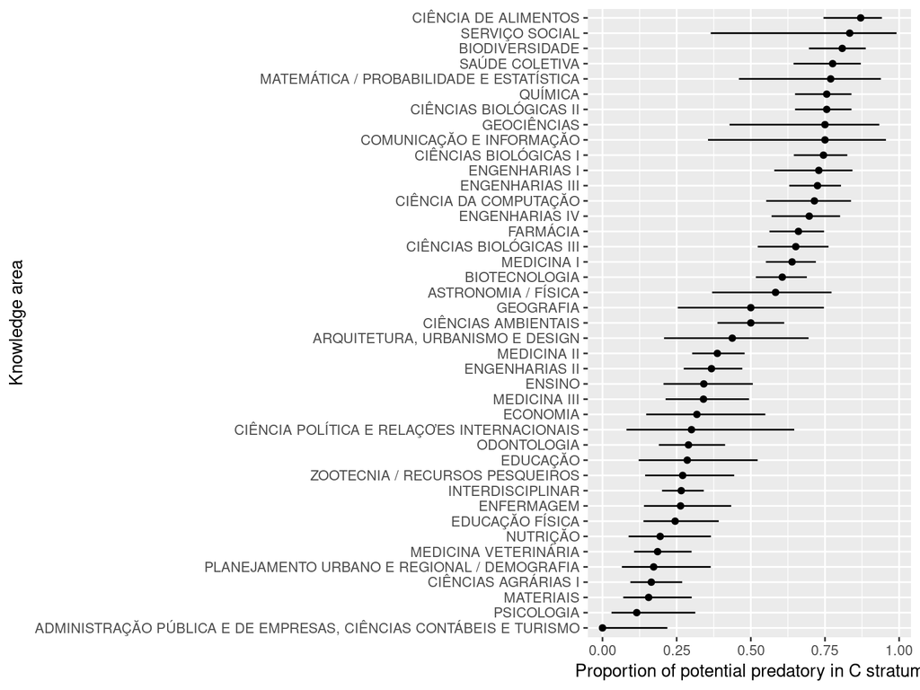

## Discussão e questões

- Uma proporção pequena do total de periódicos é potencialmente predatória. No entanto, a lista de potenciais predatórios que compilamos não está completa. Ainda assim, parece pouco provável que a proporção real de títulos potencialmente predatórios nos quais os programas de pós-graduação publicam chegue a 5%. Por outro lado, seria preciso avaliar a proporção da produção está nestes periódicos. Mais importante, apesar de baixa a proporção mostra que na maioria das áreas há pessoas que publicaram nestes veículos.
- Se a proporção de potenciais predatórios em relação ao total de títulos no QUALIS não é alarmante, a proporção que não é classificada no estrato C impressiona. A mediana do percentual de potenciais predatórios classificados como C é  
  50%. Ou seja, a maioria das áreas mantem na avaliação cerca de metade do títulos potencialmente predatórios.
- Outro ponto importante é a grande heterogeneidade das áreas quanto a essa “detecção de potenciais predatórios”. Apesar disso, não há uma tendência clara entre agrupamentos dessa áreas, como grandes áreas, colégios ou áreas mais aplicadas e básicas. Isso acontece porque em quase todos estes grupos há pelo menos uma área que foge ao padrão. Por exemplo, nas Agrárias, que têm em geral detecção baixa, Alimentos mostra valores altos. Já entre as Engenharias que têm valores mais altos, a Engenharia II é discrepante.
- Assim, o sistema QUALIS é muito vulnerável a periódicos predatórios. No momento trabalhamos com a hipótese de que os critérios de classificação nos estratos das áreas não são suficientes para detectar predatórios, por duas razões principais: (i) critério para estratos altos focado no fator de impacto e (ii) critérios para estrato médio focado em presença em bases de indexação, número de artigos da área na revista e critérios subjetivos. * No primeiro caso, em geral os estratos mais altos são definidos por ter fator de impacto medido pelo JCR nos quartis mais altos de impacto dos periódicos da área. Isso pode excluir muitos predatórios, mas alguns que entraram na lista justamente por práticas questionáveis para aumentar o fator de impacto. Dois casos famosos são *Oncotarget* e *Aging*, ambos da editora comercial Impact Journals , editados por Mikhail V. Blagosklonnye. A página da editora é vazia (http://www.impactjournals.com/) e há fortes indícios de que estes periódicos usem práticas condenáveis para aumentar impacto, sob o comando de Blagosklonnye [^4]. Estes dois periódicos e mais um da mesma editora, *Genes & Cancer* são A1 de várias áreas das Ciências da Vida. Buscamos agora exemplos análogos de outra áreas do conhecimento. * No segundo caso, o critério de impacto é substituído ou ponderado pela mera presença em certas bases bibliográficas, além da WoS. SCOPUS, PubMed e Scielo são alguns exemplos. A presença de periódicos predatórios mesmo em bases como a SCOPUS indica que este critério é problemático. Reforça este argumento que cerca de 30% dos títulos de editoras apontadas como predatórias por Bealls foram “descontinuados” da SCOPUS em 2017. Muitas áreas também usam como critério adicional para pontuar no QUALIS o quanto a área publica no periódico, o que evidentemente tem potencial para retroalimentar o uso de periódicos predatórios. Por fim, há vários critérios mais subjetivos de importância dos periódicos, e que muitas vezes não estão claros nos documentos de avaliação.
- Um ponto importante é que a maioria dos periódicos potencialmente predatórios foi avaliada por mais de uma área, sendo que na maioria dos casos pelo menos uma área os classificou como “C”. Vale também notar que nos documentos de área ou de avaliação não há menção explícita a nenhum dos critérios do Bealls ou de outros autores e instituições para detectar periódicos predatórios.

# Planilhas

Planilhas com dados processados, usados nas análises

- Base QUALIS com indicação dos potencialmente predatórios
- Número de periódicos e de potenciais predatórios por área e estrato
- Proporção de potenciais predatórios por área e estrato

# Contato

Paulo Inácio Prado & Roberto Kraenkel

14 de novembro de 2017